# shelter-animal-outcomes-in-the-united-states

$${\Large\textbf{ Shelter Animal Outcomes}}$$
$${\Large\textbf{in the United States:}}$$

$${\Large\textbf{An Application of Negative}}$$
$${\Large\textbf{Binomial Regression in R}}$$
$${\small\textbf{Kristina Diaz-Kerkado}} \
\\
{\small\textbf{ Adviser: Dr. Samantha Seals}}$$

## Table of Contents

1. Introduction
   - Statement of Problem
   - Relevance of Problem
   - Lit. Review
2. Data
   - Variables
   - Descriptions
3. Methods
   - Statistical Methods
   - Results
3. Conclusion
   - Summary Interpretation
   - Suggestions for Further Study
4. References

# Introduction

## Statement of Problem

Pets are cute. However, we know that cats and dogs end up in shelters for various reasons. No matter the reason, these cute animals have an uncertain end.  
We want to model the data of pets that end up in shelters in the United States, and predict their outcomes using R.

## Relevance of Problem

Shelter Animal Count The National Database (**SAC**)

- Non-profit
- Standardized National System
- Started in 2012
- Provides facts
- To save lives

## Literature Review

Organizational and Socioeconomic Factors that Affect Management of Pet Populations in Shelters(Andrews 2021)

- Dependent Variable : Live release rate(LLR)
  - Live outcomes divided by all other outcomes
- Independent Variables:
  - **Poverty (Poverty rate has a negative impact on LRR)**
  - **Shelter Type (Private shelter types have the largest positive effect on LRR)**
  - Rural or Urban shelters (Urban shelters have higher LRR than rural shelters)
  - Shelter size (The number of housed canines or felines positively relates to LRR)
  - **Pets transferred in (Shelter pet transport in has a positive effect on LRR)**
- Control : Species
  - Dogs and Cats

# Data

## Response Variables

Our response variables are composed of SAC’s dataset:

| Intakes | Live Outcomes | Other Outcomes |
| --- | --- | --- |
| Stray/At Large | Adoption | Died in care |
| Relinquished by Owner | Return to Owner | Lost in care |
| Owner Intended Euthanasia | Transferred out to agency (in state) | Shelter Euthanasia |
| Transferred in from agency (in state) | Transferred out to agency (out of state) | Owner Intended Euthanasia |
| Transferred in from agency (out of state) | Transferred out to agency (international) |  |
| Transferred in from agency (international) | Returned to Field |  |
| Impound/Seizure | Other live outcomes |  |
| Other Intakes |  |  |

We excluded Owner Intended Euthanasia from our Intakes and Other Outcomes totals.

## Predictor Variables

Our predictor variables are composed of:

- Year
  - 2012-2021
- Population
  - In Millions by state from US Census
- Income
  - By $5,000’s by state from US Census
- Species
  - Cats and dogs from SAC
- Democratic
  - Percentage points for 4-year period from The American Presidency Project

# Methods

## Modeling: Poisson Regression

Since our response variables are discrete data, we can use Poisson Regression to model our count outcomes.

$$\begin{aligned}
\ln ( \operatorname{Yf}) &= \beta_{0} + \beta_{1}\operatorname{X_1} + \beta_{2}\operatorname{X_2} +
... +
\beta_{k}\operatorname{X_k}\
\end{aligned}$$

```r
glm(outcome ~ predictor1 + predictor2 + ..., data = dataset,
    family = "poisson")
```

Different from linear regression in that we are modeling the natural log of counts instead of actual counts.

$$\begin{aligned}
\ \operatorname{Y} &= \beta_{0} + \beta_{1}\operatorname{X_1} + \beta_{2}\operatorname{X_2} +
... +
\beta_{k}\operatorname{X_k}\
\end{aligned}$$

```r
lm(outcome ~ predictor1 + predictor2 + ..., data = dataset)
```

## Poisson Interpretations

In Poisson regression, we convert our $\widehat\beta_i$ values to incident rate ratios(IRR).

IRR$_i = \exp(\widehat\beta_i)$

If IRR > 1, then that indicates an increase in our expected count.  
If IRR < 1, then that indicates a decrease in our expected count.

On average, [category predictor] expected [outcome] count is [100($e^{\beta_i}$-1)% or 100(1-$e^{\beta_i}$)%] [higher or lower] than [reference category] expected [outcome] count.

For a 1 [unit of predictor] increase in [predictor name], the expected count of [outcome] are [increased or decreased] by [100($e^{\beta_i}$-1)% or 100(1-$e^{\beta_i}$)%].

## Statistcal Test for $\beta_i$

To test the significance of our predictors, we use Wald’s Z test.

**Hypotheses**

$H_0: \beta_i = 0$

$H_1: \beta_i \neq 0$

**Test Statistic**

$Z_0 = \frac{\widehat\beta_i-0}{SE_{\widehat\beta_i}}$

**Rejection Region**

Reject $H_0$ if $p < \alpha$

```r
summary(model) or tab_model(model)
```

## Poisson Assumptions

**Poisson Regression assumes a Poisson distribution.**

We need to check if the means are equal to the variances.

**If the assumption is broken:**

Data is over-dispersed

Underestimating the standard errors

Test statistics ($\widehat\beta$/stderr) become larger

$p$-values smaller

Type I Error

## Negative Binomial Regression

Since we don’t want to say there is a relationship when there isn’t, we can use Negative Binomial Regression(NBR) as an alternative.

$$\begin{aligned}
\ \ln(\operatorname{Y}) &= \beta_{0} + \beta_{1}\operatorname{X_1} + \beta_{2}\operatorname{X_2} +
... +
\beta_{k}\operatorname{X_k}\
\end{aligned}$$

The NBR includes a parameter which accounts for the over-dispersion in the data.

```r
glm.nb(outcome ~ predictor1 + predictor2 + ..., data = dataset)
```

# Results

## Histograms

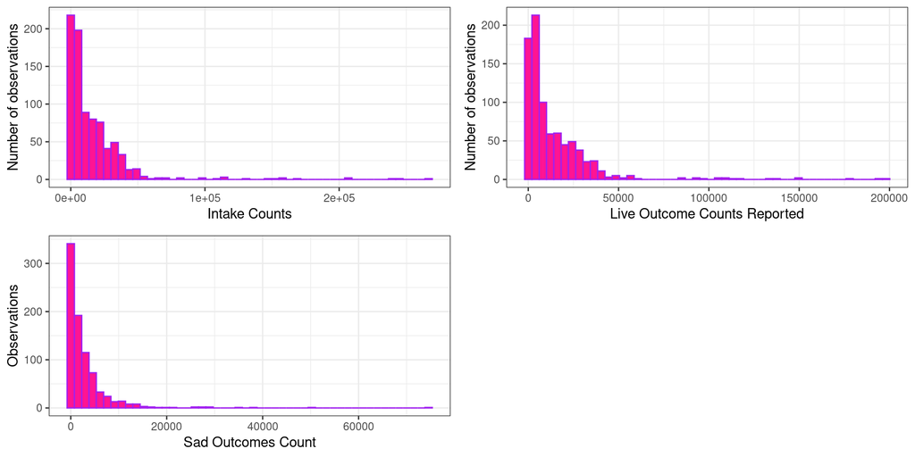

Skewed right

## Assumption Check

|  | Intakes | Live Outcomes | Other Outcomes |
| --- | --- | --- | --- |
| Mean | 16412.49 | 13972.02 | 2838.94 |
| Variance | 676569396 | 437922843 | 25967030 |

Mean<sub>$i$</sub> $\neq$ Var<sub>$i$</sub>

We do not have a Poisson distribution.

## Descriptives

Descriptive Summary

| Characteristic | Min | P25 | Median | P75 | Max |
| --- | --- | --- | --- | --- | --- |
| Population | 0.58 | 1.79 | 4.41 | 6.91 | 39.51 |
| Income | 7.44 | 10.14 | 11.51 | 13.36 | 18.39 |
| Democratic | 21.90 | 38.10 | 46.80 | 54.30 | 92.15 |
| Intakes | 27.00 | 2539.00 | 8313.00 | 21859.00 | 266706.00 |
| Happy Outcomes | 18.00 | 2576.00 | 6702.00 | 19496.00 | 198149.00 |
| Sad Outcomes | 1.00 | 249.00 | 1228.00 | 3525.50 | 74599.00 |

## Models

$$\begin{aligned}
\ln (\operatorname{Intakes}) &= -598.5239 + 0.3018(\operatorname{Year}) + 0.1001(\operatorname{Population}) - 0.1067(\operatorname{Income})\ \\
&\quad - 0.0731(\operatorname{Species}_{\operatorname{Dogs}}) - 0.0005(\operatorname{Democratic})
\end{aligned}$$

$$\begin{aligned}
\ln(\operatorname{Live Outcomes}) &= -659.8284 + 0.3318(\operatorname{Year}) + 0.1028(\operatorname{Population}) - 0.0381(\operatorname{Income})\ \\
&\quad + 0.1468(\operatorname{Species}_{\operatorname{Dogs}}) - 0.0061(\operatorname{Democratic})
\end{aligned}$$

$$\begin{aligned}
\ln( \operatorname{Other Outcomes}) &= -364.6637 + 0.1853(\operatorname{Year}) + 0.0956(\operatorname{Population}) - 0.1965(\operatorname{Income})\ \\
&\quad - 0.6646(\operatorname{Species}_{\operatorname{Dogs}}) + 0.0139(\operatorname{Democratic})
\end{aligned}$$

## Intakes Model

$$\begin{aligned}
\ln (\operatorname{Intakes}) &= -598.5239 + 0.3018(\operatorname{Year}) + 0.1001(\operatorname{Population}) - 0.1067(\operatorname{Income})\ \\
&\quad - 0.0731(\operatorname{Species}_{\operatorname{Dogs}}) - 0.0005(\operatorname{Democratic})
\end{aligned}$$

Predictors for Intakes

|  | Intakes |  |  |
| --- | --- | --- | --- |
| Predictors | Incidence Rate Ratios | CI | p |
| (Intercept) | 0.00 | 0.00 – 0.00 | **<0.001** |
| Year | 1.35 | 1.31 – 1.40 | **<0.001** |
| Population | 1.11 | 1.09 – 1.12 | **<0.001** |
| Income | 0.90 | 0.86 – 0.94 | **<0.001** |
| Species [Dogs] | 0.93 | 0.82 – 1.06 | 0.261 |
| Democratic | 1.00 | 0.99 – 1.01 | 0.885 |
| Observations | 839 |  |  |
| R<sup>2</sup> Nagelkerke | 0.696 |  |  |

## Live Outcomes Model

$$\begin{aligned}
\ln(\operatorname{Live Outcomes}) &= -659.8284 + 0.3318(\operatorname{Year}) + 0.1028(\operatorname{Population}) - 0.0381(\operatorname{Income})\ \\
&\quad + 0.1468(\operatorname{Species}_{\operatorname{Dogs}}) - 0.0061(\operatorname{Democratic})
\end{aligned}$$

Predictors for Happy Outcomes

|  | Happy Outcomes |  |  |
| --- | --- | --- | --- |
| Predictors | Incidence Rate Ratios | CI | p |
| (Intercept) | 0.00 | 0.00 – 0.00 | **<0.001** |
| Year | 1.39 | 1.35 – 1.44 | **<0.001** |
| Population | 1.11 | 1.09 – 1.12 | **<0.001** |
| Income | 0.96 | 0.93 – 1.00 | **0.043** |
| Species [Dogs] | 1.16 | 1.03 – 1.30 | **0.015** |
| Democratic | 0.99 | 0.99 – 1.00 | 0.058 |
| Observations | 839 |  |  |
| R<sup>2</sup> Nagelkerke | 0.771 |  |  |

## Other Outcomes Model

$$\begin{aligned}
\ln( \operatorname{Other Outcomes}) &= -364.6637 + 0.1853(\operatorname{Year}) + 0.0956(\operatorname{Population}) - 0.1965(\operatorname{Income})\ \\
&\quad - 0.6646(\operatorname{Species}_{\operatorname{Dogs}}) + 0.0139(\operatorname{Democratic})
\end{aligned}$$

Predictors for Sad Outcomes

|  | Sad Outcomes |  |  |
| --- | --- | --- | --- |
| Predictors | Incidence Rate Ratios | CI | p |
| (Intercept) | 0.00 | 0.00 – 0.00 | **<0.001** |
| Year | 1.20 | 1.15 – 1.26 | **<0.001** |
| Population | 1.10 | 1.08 – 1.12 | **<0.001** |
| Income | 0.82 | 0.78 – 0.87 | **<0.001** |
| Species [Dogs] | 0.51 | 0.44 – 0.61 | **<0.001** |
| Democratic | 1.01 | 1.00 – 1.02 | **0.002** |
| Observations | 839 |  |  |
| R<sup>2</sup> Nagelkerke | 0.482 |  |  |

## Multicollinearity Check

VIF: Multicollinearity Check

| Predictor | Intakes | Live Outcomes | Other Outcomes |
| --- | --- | --- | --- |
| Year | 1.560438 | 1.560420 | 1.560560 |
| Population | 1.050983 | 1.050991 | 1.050982 |
| Income | 2.075031 | 2.075028 | 2.075226 |
| Species | 1.000234 | 1.000234 | 1.000233 |
| Democratic | 1.618125 | 1.618145 | 1.618250 |

# Conclusion

## All Models

Significance

|  | Intakes |  |  | Happy Outcomes |  |  | Sad Outcomes |  |  |
| --- | --- | --- | --- | --- | --- | --- | --- | --- | --- |
| Predictors | Incidence Rate Ratios | CI | p | Incidence Rate Ratios | CI | p | Incidence Rate Ratios | CI | p |
| Year | 1.35 | 1.31 – 1.40 | **<0.001** | 1.39 | 1.35 – 1.44 | **<0.001** | 1.20 | 1.15 – 1.26 | **<0.001** |
| Population | 1.11 | 1.09 – 1.12 | **<0.001** | 1.11 | 1.09 – 1.12 | **<0.001** | 1.10 | 1.08 – 1.12 | **<0.001** |
| Income | 0.90 | 0.86 – 0.94 | **<0.001** | 0.96 | 0.93 – 1.00 | **0.043** | 0.82 | 0.78 – 0.87 | **<0.001** |
| Species [Dogs] | 0.93 | 0.82 – 1.06 | 0.261 | 1.16 | 1.03 – 1.30 | **0.015** | 0.51 | 0.44 – 0.61 | **<0.001** |
| Democratic | 1.00 | 0.99 – 1.01 | 0.885 | 0.99 | 0.99 – 1.00 | 0.058 | 1.01 | 1.00 – 1.02 | **0.002** |
| Observations | 839 |  |  | 839 |  |  | 839 |  |  |
| R<sup>2</sup> Nagelkerke | 0.696 |  |  | 0.771 |  |  | 0.482 |  |  |

## Data Visualization

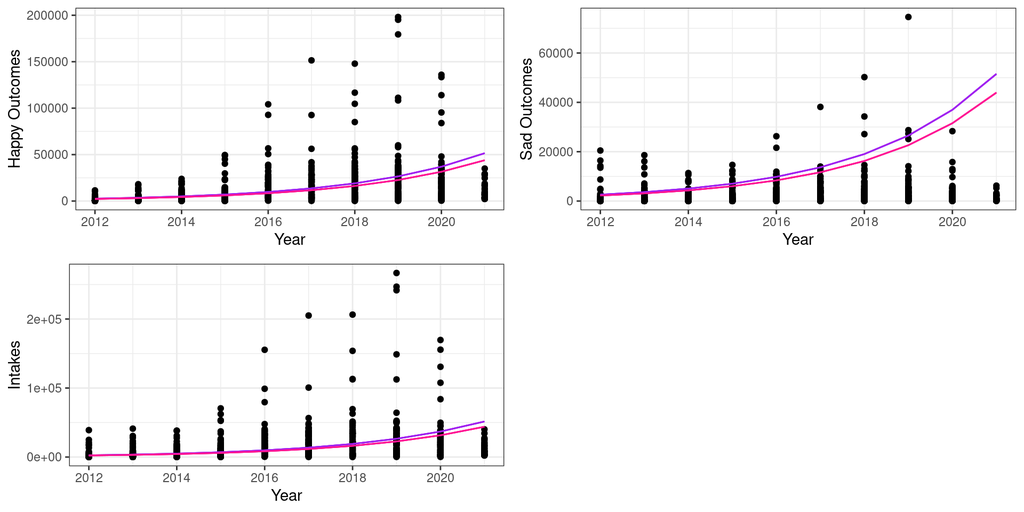

## Summary

- Year, population and income were significant predictors of all of our models with $p$-values all < $\alpha$.
- Species was not a significant predictor for Intake counts, but it was a significant predictor for live outcome counts and other outcome counts.
- Democratic percentage point was only a significant predictor for other outcome counts.

## Future Research

- This can be reproduced with months instead of year since the shelters reported monthly observations.
- By state.
- By zip code.
- Include animal attributes.
- Covid effect on intakes and outcomes.

## References

[figure not shown]

Andrews, Sean P. 2021. “MIXED METHODS STUDY EXAMINING ORGANIZATIONAL AND SOCIOECONOMIC FACTORS AFFECTING MANAGEMENT OF PET POPULATIONS IN SHELTERS.” CASE WESTERN RESERVE UNIVERSITY.